# Investigate poor coverage for ash.hu

Matthew Stephens

2015-10-26

**Last updated:** 2017-01-15

**Code version:** b05decc05714ddcb20aa04e56b557d5123d178fb

First, we load the necessary libraries.

```r
library(ashr)
library(reshape2)
library(ggplot2)
library(dplyr)
library(dscr)
```

Compile the tables which we will use to examine the results of the simulation experiments.

```r
load("../output/dsc-shrink-files/res.RData")

neglong =
  res$negprob %>%
    select(-user.self,-sys.self,-elapsed,-user.child,-sys.child) %>%
    melt(id.vars = c("method","scenario","seed",".id"),value.name = "negprob") %>%
    filter(negprob > 0.95)

poslong =
  res$posprob %>%
    select(-user.self,-sys.self,-elapsed,-user.child,-sys.child) %>%
    melt(id.vars = c("method","scenario","seed",".id"),value.name = "posprob") %>%
    filter(posprob > 0.95)

reslong =
  res$cdf_score %>%
    select(-user.self,-sys.self,-elapsed,-user.child,-sys.child) %>%
    melt(id.vars = c("method","scenario","seed",".id"))

reslong.pos = inner_join(reslong,poslong)
reslong.neg = inner_join(reslong,neglong)
ash.hu.ft = reslong.pos %>% filter(method == "ash.hu.s" &
                                   scenario == "flat-top")
```

Extract an example to illustrate coverage of ash.hu.

```r
eg = load_example(dsc_shrink,42,"flat-top",methodname = "ash.hu.s",
                  homedir = "../code/dsc-shrink")
out        <- eg$output$fitted_g
class(out) <- "list"
out        <- as.data.frame(out)
print(subset(out,pi > 0.01))
```

```
        pi      a       b
10 0.02742 -1.795 0.00000
15 0.42292  0.000 0.07932
16 0.50655  0.000 0.11218
24 0.04312  0.000 1.79483
```

Now let’s look at an example with u and spiky which seems to be somewhat badly calibrated for the negative discoveries.

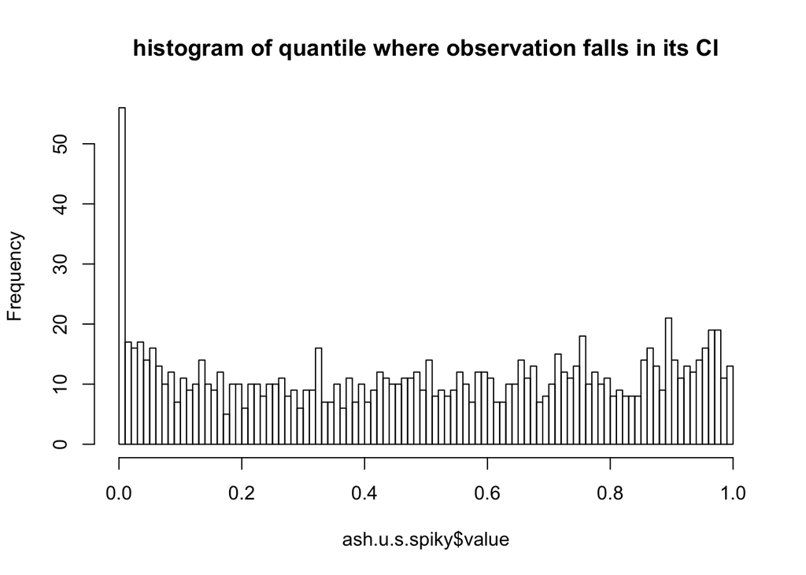

```r
ash.u.s.spiky = reslong.neg %>% filter(method == "ash.u.s" &
                                       scenario == "spiky")
ash.n.s.spiky = reslong.neg %>% filter(method == "ash.n.s" &
                                         scenario == "spiky")
hist(ash.u.s.spiky$value,nclass = 100,
     main = paste("histogram of quantile where observation falls in its CI"))
```

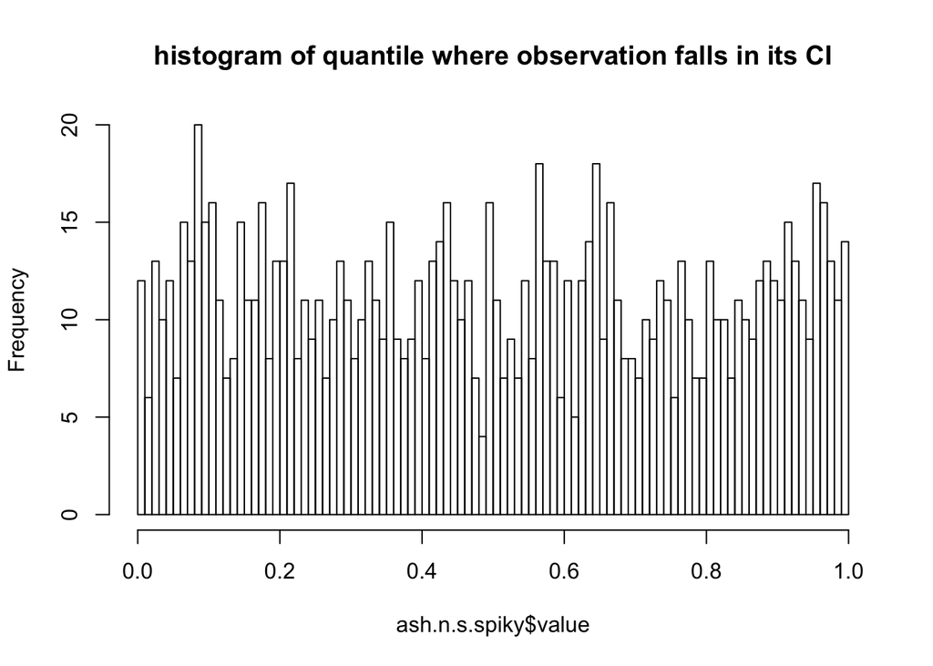

```r
hist(ash.n.s.spiky$value,nclass = 100,
     main = paste("histogram of quantile where observation falls in its CI"))
```

So what seems to be happening here is that the uniform tail is too short; when observation falls outside of this tail it gets a zero quantile of posterior interval.

Can we find an example illustrating this trend? (Note: the next chunk below did not work for me, so I se* `eval=FALSE, include=FALSE`. Perhaps this can be fixed at some point. -Peter)

For comparison, here are the positive discoveries; here they are not too bad.

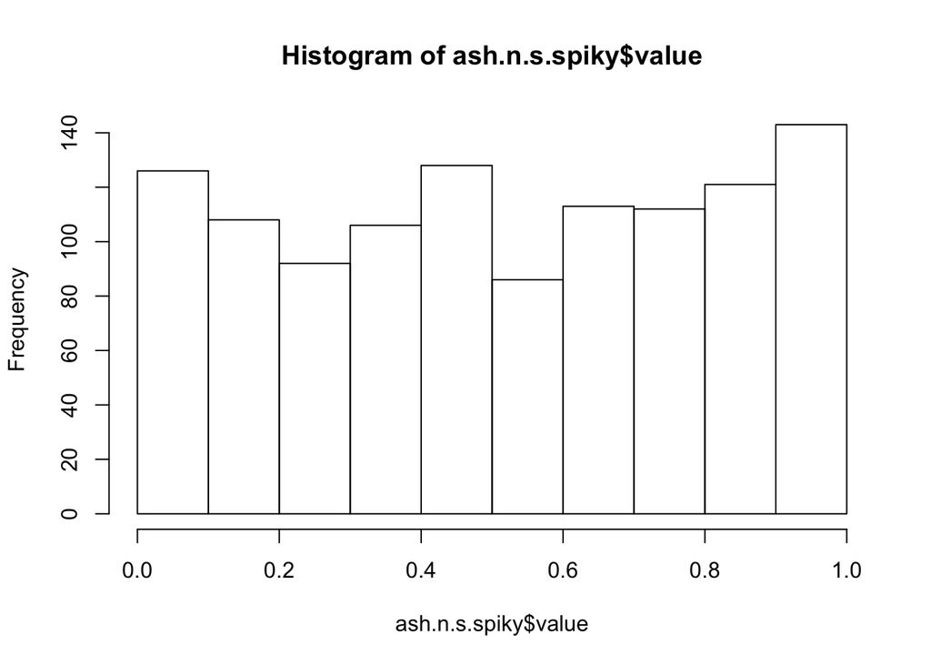

```r
ash.u.s.spiky = reslong.pos %>% filter(method == "ash.u.s" & scenario == "spiky")
ash.n.s.spiky = reslong.pos %>% filter(method == "ash.n.s" & scenario == "spiky")
hist(ash.n.s.spiky$value)
```

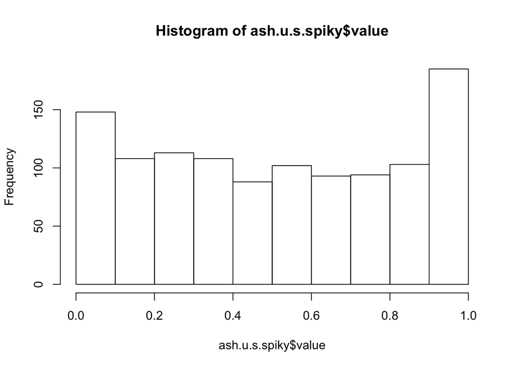

```r
hist(ash.u.s.spiky$value)
```